# Levelling up: How to unlock ecological and evolutionary data with hierarchical - Supplementary Material

## 4.4 Step 4: Box 3 - *Prediction*

### 4.4.1 Process the data

Here we use `d_crop`, previously processed in Box 2, and further prepare it for this section.

```r
# Add a rare/undersampled species for Example 1
d_crop_rare <- readRDS(here::here("prediction", "example_rare_species.rds"))

d_crop_merged <- rbind(d_crop, d_crop_rare)

# Rename columns and adjust abundance
dat <- d_crop_merged %>%
  rename(
    y = ABUNDANCE,
    series = valid_name, # for the mvgam requirement
    lat = LATITUDE,
    long = LONGITUDE,
    time = YEAR # for the mvgam requirement
  )

dat <- dat %>%
  group_by(time) %>%
  mutate(total_abun = sum(y)) %>%
  mutate(rel_abun = y / total_abun) %>%
  select(-total_abun)
```

#### 4.4.1.1 `mvgam` format requirements

Prepare and format the dataset for HGAM fitting and forecasting: adjust columns to meet mvgam requirements, define training/testing subsets, and create datasets with and without specific species for out-of-sample forecasts.

```r
## Adjust columns for mvgam requirements
dat$y <- as.vector(dat$y)
dat <- filter(dat, series != "Vireo olivaceus")
dat$series <- as.factor(dat$series)
dat$time <- as.integer(dat$time) - min(dat$time)

# Subset the data in training and testing folds
data_train <- dat[which(d_crop$YEAR <= 1999), ]
data_test <- dat[which(d_crop$YEAR > 2000), ]

# subsetting the data with and without a species for out-of-sample forecasting
# Remove Setophaga pinus due to missing observations in some years

data_noMniotilta <- filter(dat, series != "Mniotilta varia" & series != "Setophaga pinus")
data_Mniotilta <- filter(dat, series == "Mniotilta varia")
```

### 4.4.2 Fit Models

#### 4.4.2.1 Inspect and visualize training and testing data

Finalize and visualize data subsets: unused factor levels are removed, the temporal extent of the test set is verified, and all series are plotted to assess coverage between training and testing periods.

```r
set.seed(2505)

data_train <- data_train %>%
  droplevels()
data_test <- data_test %>%
  droplevels()

range(data_test$time)
```

```
[1] 23 29
```

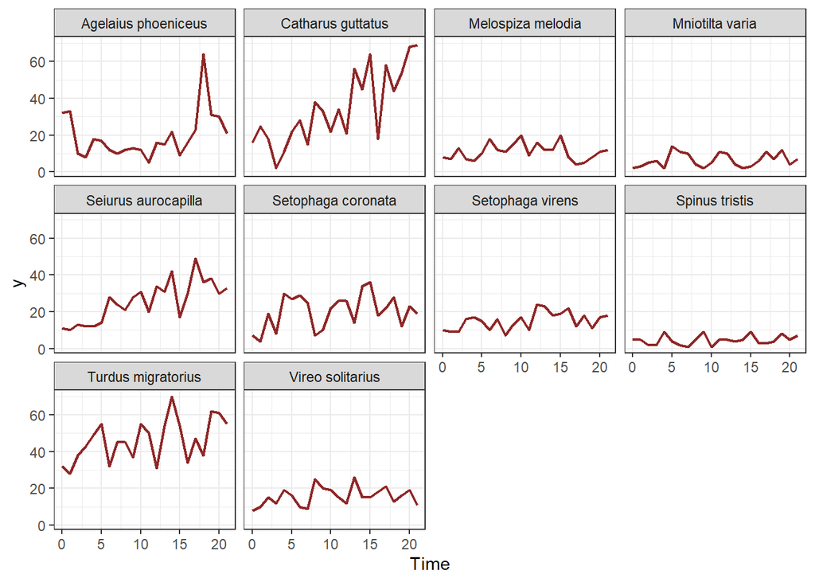

```r
# Plot series
plot_mvgam_series(
  data = data_train,
  newdata = data_test,
  series = "all"
)
```

#### 4.4.2.2 Penalized splines forecast: `mod_forecast_ps`

A State-Space hierarchical GAM is fitted using a Poisson family, AR(1) temporal dynamics, and penalized spline smooths. The model structure incorporates hierarchical time effects for computational efficiency and summarizes key outputs excluding beta estimates.

```r
# Set up a State-Space hierarchical GAM with AR1 dynamics for autocorrelation
# Smooths are penalized splines
# mod_forecast_ps <- mvgam(
#   data = data_train,
#   formula = y ~
#     s(series, bs = "re"),
#
#   # Hierarchical smooths of time set up as a
#   # State-Space model for sampling efficiency
#   trend_formula = ~
#     s(time, bs = "tp", k = 6) +
#       s(time, trend, bs = "sz", k = 6),
#   family = poisson(),
#
#   # AR1 for "residual" autocorrelation
#   trend_model = AR(p = 1),
#   noncentred = TRUE,
#   priors = prior(exponential(2),
#     class = sigma
#   ),
#   backend = "cmdstanr"
# )

# Read the model
mod_forecast_ps <- readRDS(here::here("prediction", "output", "mod_forecast_ps.rds"))
```

##### 4.4.2.2.1 Model summary

```r
summary(mod_forecast_ps, include_betas = FALSE)
```

```
GAM observation formula:
y ~ +s(series, bs = "re")

GAM process formula:
~s(time, bs = "tp", k = 6) + s(time, trend, bs = "sz", k = 6)

Family:
poisson

Link function:
log

Trend model:
AR(p = 1)


N process models:
10

N series:
10

N timepoints:
22

Status:
Fitted using Stan
4 chains, each with iter = 1000; warmup = 500; thin = 1
Total post-warmup draws = 2000


GAM observation model coefficient (beta) estimates:
            2.5% 50% 97.5% Rhat n_eff
(Intercept) -1.1 2.7   6.1    1  1516

GAM observation model group-level estimates:
                 2.5%    50% 97.5% Rhat n_eff
mean(s(series)) -1.90 -0.025   1.9    1  3102
sd(s(series))    0.45  0.750   1.4    1   757

```

[output cut: 40 more lines]

```

Stan MCMC diagnostics:
n_eff / iter looks reasonable for all parameters
Rhat looks reasonable for all parameters
0 of 2000 iterations ended with a divergence (0%)
1106 of 2000 iterations saturated the maximum tree depth of 10 (55.3%)
 *Run with max_treedepth set to a larger value to avoid saturation
E-FMI indicated no pathological behavior

Samples were drawn using NUTS(diag_e) at Wed Oct 15 1:39:31 PM 2025.
For each parameter, n_eff is a crude measure of effective sample size,
and Rhat is the potential scale reduction factor on split MCMC chains
(at convergence, Rhat = 1)

Use how_to_cite(mod_forecast_ps) to get started describing this model
```

##### 4.4.2.2.2 Plots

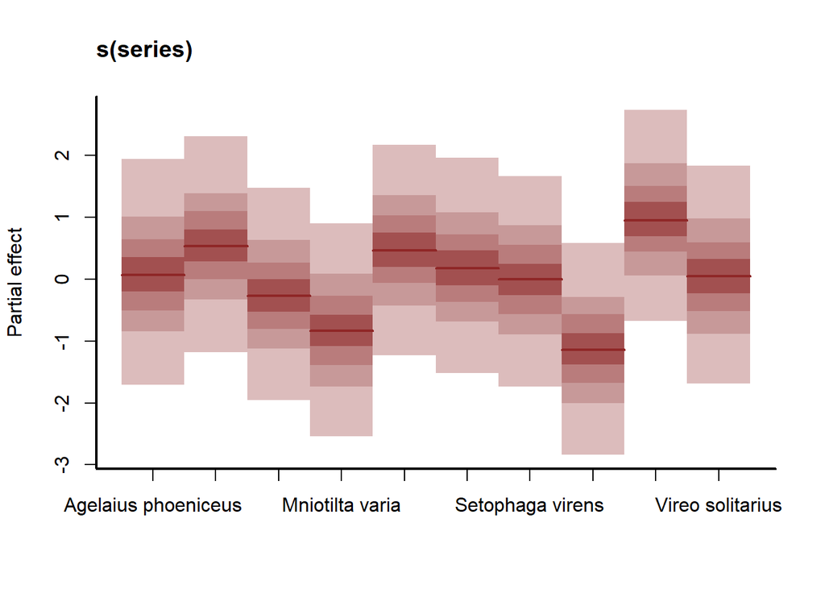

```r
# Plot random effects
mvgam::plot_mvgam_randomeffects(mod_forecast_ps)
```

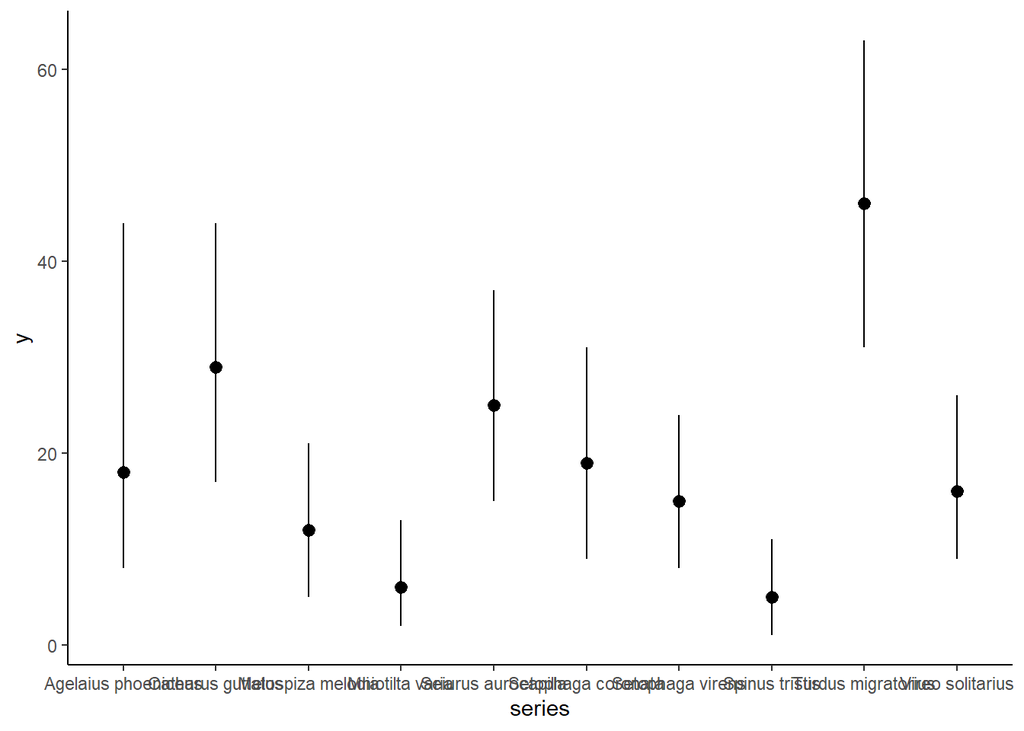

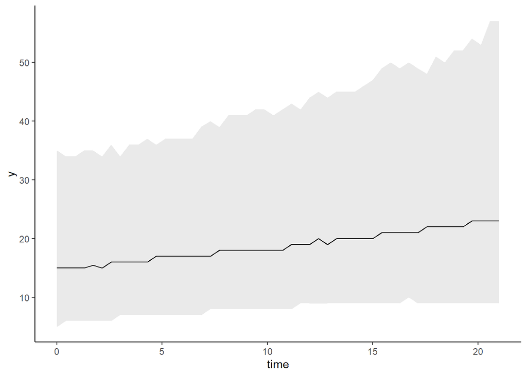

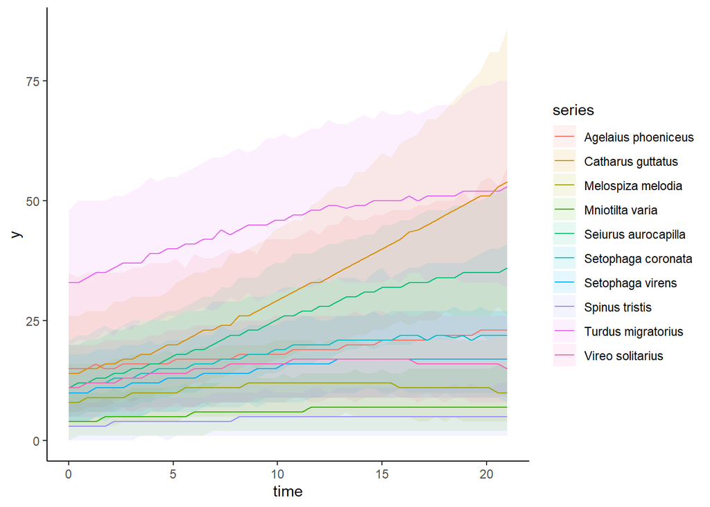

```r
# Condtional effects
conditional_effects(mod_forecast_ps)
```

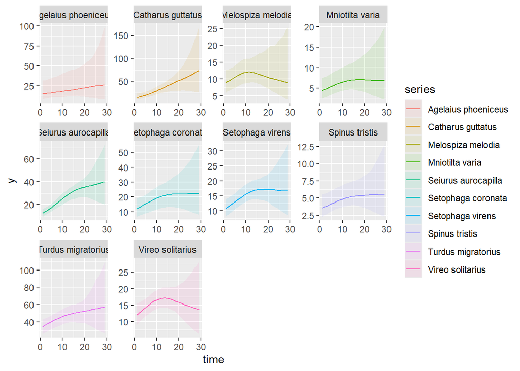

```r
# Forecast penalized splines
forecast_penalized_splines <- plot_predictions(
  mod_forecast_ps,
  by = c("time", "series", "series"),
  newdata = datagrid(
    time = 1:max(data_test$time),
    series = unique
  ),
  type = "expected"
)
forecast_penalized_splines
```

Obviously the splines show high extrapolation uncertainty into the test time points, but that is ok as it isn’t the focus of this exercise. But if we wanted better forecasts, let’s use GPs in place of the penalized smooths. [Source](https://ecogambler.netlify.app/blog/autocorrelated-gams/) used.

##### 4.4.2.2.3 Look at some of the AR1 estimates

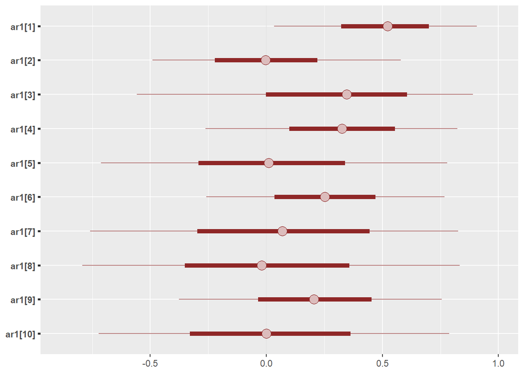

```r
# Look at some of the AR1 estimates
mcmc_plot(mod_forecast_ps, variable = "ar1", regex = TRUE)
```

#### 4.4.2.3 Gaussian process forecasts : `mod_forecast_GP`

This model replaces penalized spline smooths with Gaussian Process terms to more flexibly model temporal dependencies and enhance forecasting accuracy.

```r
# Using Gaussian Process in place of penalized smooths to get better forecasts
# mod_forecast_GP <- mvgam(
#   data = data_train,
#   formula = y ~
#     s(series, bs = "re"),
#
#   # Hierarchical smooths of time set up as a
#   # State-Space model for sampling efficiency
#   trend_formula = ~
#     gp(time, k = 6) +
#       s(time, trend, bs = "sz", k = 6),
#   family = poisson(),
#
#   # AR1 for "residual" autocorrelation
#   trend_model = AR(p = 1),
#   noncentred = TRUE,
#   priors = prior(exponential(2),
#     class = sigma
#   ),
#   backend = "cmdstanr"
# )

# Read the model
mod_forecast_GP <- readRDS(here::here("prediction", "output", "mod_forecast_GP.rds"))
```

##### 4.4.2.3.1 Model summary

```r
summary(mod_forecast_GP, include_betas = FALSE)
```

```
GAM observation formula:
y ~ +s(series, bs = "re")

GAM process formula:
~gp(time, k = 6) + s(time, trend, bs = "sz", k = 6)

Family:
poisson

Link function:
log

Trend model:
AR(p = 1)


N process models:
10

N series:
10

N timepoints:
22

Status:
Fitted using Stan
4 chains, each with iter = 1000; warmup = 500; thin = 1
Total post-warmup draws = 2000


GAM observation model coefficient (beta) estimates:
             2.5% 50% 97.5% Rhat n_eff
(Intercept) -0.97 2.6   6.3    1  2947

GAM observation model group-level estimates:
                 2.5%    50% 97.5% Rhat n_eff
mean(s(series)) -1.90 0.0047   1.9    1  5510
sd(s(series))    0.43 0.7300   1.4    1  1311

```

[output cut: 41 more lines]

```
Stan MCMC diagnostics:
n_eff / iter looks reasonable for all parameters
Rhat looks reasonable for all parameters
10 of 2000 iterations ended with a divergence (0.5%)
 *Try running with larger adapt_delta to remove the divergences
1920 of 2000 iterations saturated the maximum tree depth of 10 (96%)
 *Run with max_treedepth set to a larger value to avoid saturation
E-FMI indicated no pathological behavior

Samples were drawn using NUTS(diag_e) at Wed Oct 15 4:04:52 PM 2025.
For each parameter, n_eff is a crude measure of effective sample size,
and Rhat is the potential scale reduction factor on split MCMC chains
(at convergence, Rhat = 1)

Use how_to_cite(mod_forecast_GP) to get started describing this model
```

##### 4.4.2.3.2 Predict

```r
# Build prediction grid
pred_data <- data.frame(
  time = rep(1:max(data_test$time), each = length(unique(data_train$series))),
  series = rep(unique(data_train$series), times = max(data_test$time))
)

predictions <- predictions(
  mod_forecast_GP,
  newdata = pred_data,
  by = c("time", "series", "series"),
  type = "expected"
)

# Mark which points are forecasts & Add a vertical line where the train test splits (time = 22)
predictions$forecast <- ifelse(predictions$time > 22, "Forecast", "Fitted")
```

##### 4.4.2.3.3 Plot species-level forecasts

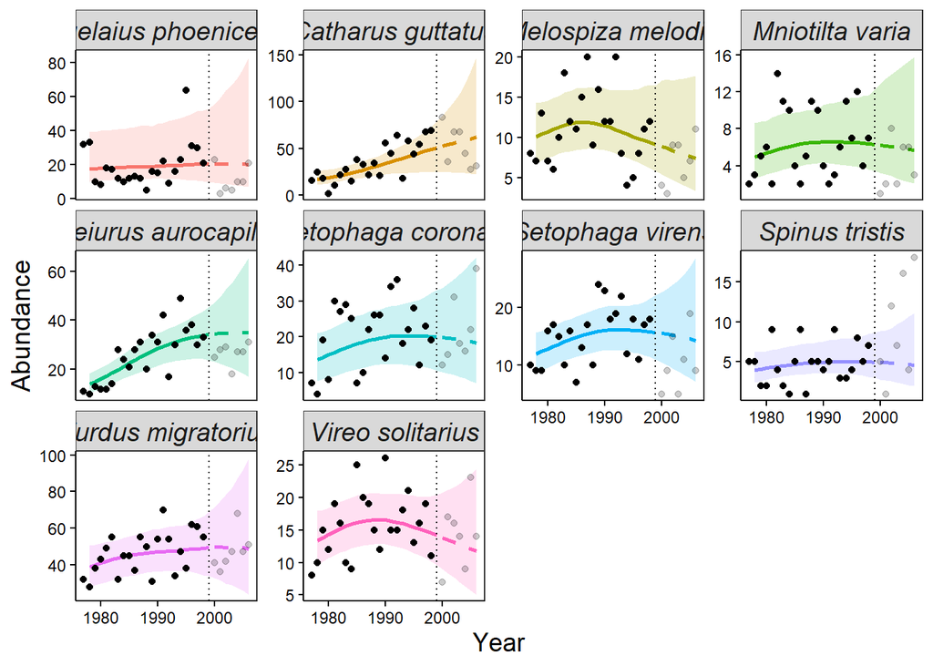

```r
# Convert time to years
predictions$year <- predictions$time + 1977
data_train$year <- data_train$time + 1977
data_test$year <- data_test$time + 1977

ggplot(predictions, aes(x = year, y = estimate)) +
  geom_ribbon(
    aes(ymin = conf.low, ymax = conf.high, fill = series),
    alpha = 0.2
  ) +
  geom_line(
    data = subset(predictions, forecast == "Fitted"),
    aes(color = series), linewidth = 1
  ) +
  geom_line(
    data = subset(predictions, forecast == "Forecast"),
    aes(color = series), linewidth = 1, linetype = "dashed"
  ) +
  geom_vline(xintercept = 1999, linetype = "dotted") +
  geom_point(data = data_train, aes(x = year, y = y), color = "black", alpha = 1) +
  geom_point(data = data_test, aes(x = year, y = y), alpha = 0.2) +
  facet_wrap(~series, scales = "free_y") +
  theme_bw() +
  theme(
    panel.grid = element_blank(),
    panel.background = element_blank(),
    axis.line = element_line(color = "black"),
    axis.ticks = element_line(color = "black"),
    axis.text = element_text(color = "black"),
    legend.position = "none",
    strip.text = element_text(size = 14, face = "italic"),
    axis.title = element_text(size = 14)
  ) +
  labs(y = "Abundance", x = "Year")
```

##### 4.4.2.3.4 Plot latent/global trend

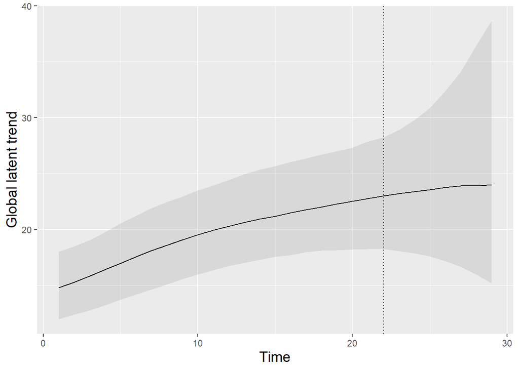

```r
plot_predictions(
  mod_forecast_GP,
  by = c("time"),
  newdata = datagrid(
    time = 1:max(data_test$time),
    series = unique
  ),
  type = "expected"
) +
  geom_vline(xintercept = 22, linetype = "dotted") +
  labs(y = "Global latent trend", x = "Time") +
  theme(axis.title = element_text(size = 14))
```

#### 4.4.2.4 Individual GAMs: comparing forecasts with no latent trend

Here, individual GAMs are fitted separately for each species without a shared latent trend. This approach is expected to show poorer forecasting performance compared to the hierarchical GP HGAM model above.

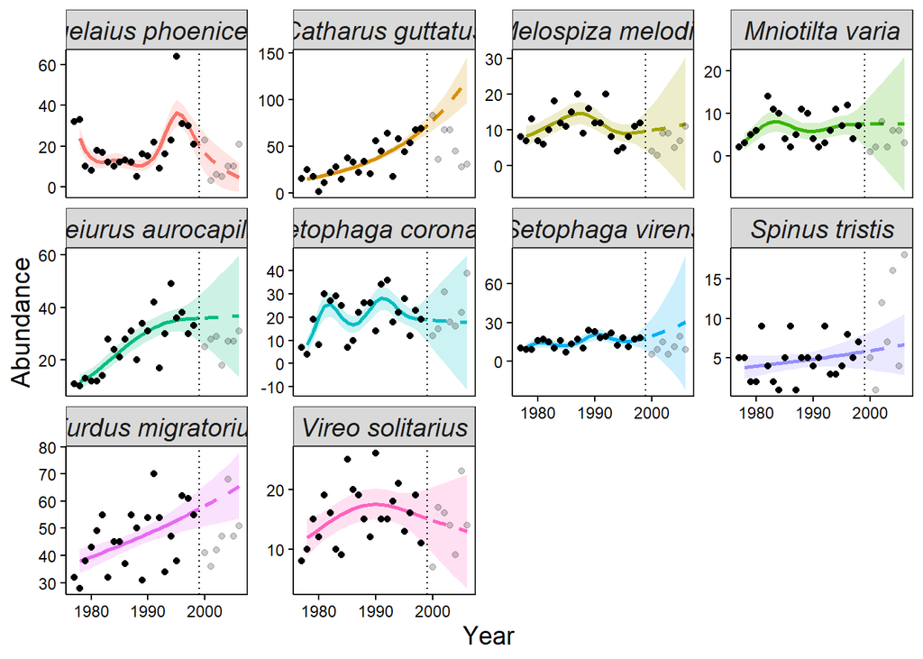

```r
set.seed(2505)

data_train <- data_train %>%
  droplevels()
data_test <- data_test %>%
  droplevels()

# Get unique species
species_list <- unique(data_train$series)

# Initialize list to store models and predictions
mod_list <- list()
pred_list <- list()

# Loop through each species and fit individual GAMs
for (sp in species_list) {
  # Subset data for this species
  train_sp <- data_train %>% filter(series == sp)

  # Fit individual GAM
  mod_list[[sp]] <- gam(y ~ s(time, bs = "tp", k = 6),
    data = train_sp,
    family = poisson()
  )

  # Generate predictions for all time points
  pred_data_sp <- data.frame(
    time = 1:max(data_test$time)
  )

  pred_sp <- predict(mod_list[[sp]],
    newdata = pred_data_sp,
    se.fit = TRUE,
    type = "response"
  )

  pred_list[[sp]] <- data.frame(
    time = pred_data_sp$time,
    series = sp,
    estimate = pred_sp$fit,
    se = pred_sp$se.fit,
    conf.low = pred_sp$fit - 1.96 * pred_sp$se.fit,
    conf.high = pred_sp$fit + 1.96 * pred_sp$se.fit
  )
}

# Combine all predictions
predictions <- bind_rows(pred_list)

# Convert to years
predictions$year <- predictions$time + 1977
data_train$year <- data_train$time + 1977
data_test$year <- data_test$time + 1977

predictions$forecast <- ifelse(predictions$time > 22, "Forecast", "Fitted")

# Plot
ggplot(predictions, aes(x = year, y = estimate)) +
  geom_ribbon(
    aes(ymin = conf.low, ymax = conf.high, fill = series),
    alpha = 0.2
  ) +
  geom_line(
    data = subset(predictions, forecast == "Fitted"),
    aes(color = series), linewidth = 1
  ) +
  geom_line(
    data = subset(predictions, forecast == "Forecast"),
    aes(color = series), linewidth = 1, linetype = "dashed"
  ) +
  geom_vline(xintercept = 1999, linetype = "dotted") +
  geom_point(data = data_train, aes(x = year, y = y), color = "black", alpha = 1) +
  geom_point(data = data_test, aes(x = year, y = y), alpha = 0.2) +
  facet_wrap(~series, scales = "free_y") +
  theme_bw() +
  theme(
    panel.grid = element_blank(),
    panel.background = element_blank(),
    axis.line = element_line(color = "black"),
    axis.ticks = element_line(color = "black"),
    axis.text = element_text(color = "black"),
    legend.position = "none",
    strip.text = element_text(size = 14, face = "italic"),
    axis.title = element_text(size = 14)
  ) +
  labs(y = "Abundance", x = "Year")
```

### 4.4.3 Gaussian process - predicting new species

#### 4.4.3.1 Black-and-white Warbler (BAWW) Post-stratification model

##### 4.4.3.1.1 Training dataset & train the model

In this section, we prepare a training dataset that excludes *Mniotilta varia* (Black-and-white Warbler) to perform post-stratification. We examine missing observations across species and time, verify data completeness, and then load the fitted state-space HGAM (Gaussian Process–based) trained on the reduced dataset.

```r
# Black-and-white Warbler Post-stratification Model ----
# Create training data excluding Mniotilta varia (Black-and-white Warbler)
data_train_noBAWW <- data_noMniotilta %>%
  droplevels()

# Set up State-Space hierarchical GAM excluding BAWW for post-stratification
set.seed(2505)
data_train_noBAWW %>%
  group_by(series) %>%
  summarise(
    n_obs = n(),
    expected_obs = length(unique(data_train_noBAWW$time)),
    missing_obs = expected_obs - n_obs
  ) %>%
  filter(missing_obs > 0)
```

```
# A tibble: 0 × 4
# ℹ 4 variables: series <fct>, n_obs <int>, expected_obs <int>,
#   missing_obs <int>
```

```r
unique(data_train_noBAWW$series)
```

```
[1] Agelaius phoeniceus Spinus tristis      Catharus guttatus
[4] Setophaga coronata  Setophaga virens    Melospiza melodia
[7] Seiurus aurocapilla Turdus migratorius  Vireo solitarius
9 Levels: Agelaius phoeniceus Catharus guttatus ... Vireo solitarius
```

```r
colSums(is.na(data_train_noBAWW))
```

```
       y   series      lat     long     time rel_abun
       0        0        0        0        0        0
```

```r
# mod_strat_BAWW <- mvgam(
#   data = data_train_noBAWW,
#   formula = y ~
#     s(series, bs = "re"),
#
#   # Hierarchical smooths of time set up as a
#   # State-Space model for sampling efficiency
#   trend_formula = ~
#     gp(time, k = 3, gr = FALSE),
#   family = poisson(),
#
#   # AR1 for "residual" autocorrelation
#   trend_model = AR(p = 1),
#   noncentred = TRUE,
#   priors = prior(exponential(2),
#     class = sigma
#   ),
#   backend = "cmdstanr"
# )

# Read the model
mod_strat_BAWW <- readRDS(here::here("prediction", "output", "mod_strat_BAWW_GP_all_years.rds"))
```

##### 4.4.3.1.2 Construct weighted prediction data for post-stratification

```r
# Post-stratification for Black-and-white Warbler prediction ---
# predict trends for all species and weight these based
# on their "distance" to the new species
unique_species_noBAWW <- levels(data_train_noBAWW$series)

# Add some weights; here a higher value means that species is "closer" to the
# un-modelled target species. This could for example be the inverse of a phylogenetic
# or functional distance metric

# Initialize all weights to 1
species_weights_BAWW <- rep(1, length(unique_species_noBAWW))
names(species_weights_BAWW) <- unique_species_noBAWW

# Assign higher weight to warblers species
# Weight it 10x higher than other species for strong post-stratification

setophaga_species <- grep("Setophaga", unique_species_noBAWW, value = TRUE)
species_weights_BAWW[setophaga_species] <- 10
species_weights_BAWW["Seiurus aurocapilla"] <- 10


# Generate the prediction grid; here we replicate each species' temporal grid
# a number of times, with the number of replications determined by the weight
# vector above
pred_dat_BAWW <- do.call(
  rbind,
  lapply(seq_along(unique_species_noBAWW), function(sp) {
    sp_name <- unique_species_noBAWW[sp]
    weight <- species_weights_BAWW[sp_name]

    do.call(
      rbind,
      replicate(
        weight,
        data.frame(
          time =
            1:max(data_train_noBAWW$time + 1), # time is indexed starting at 0
          series = sp_name
        ),
        simplify = FALSE
      )
    )
  })
) %>%
  dplyr::mutate(
    series = factor(series, levels = levels(data_train_noBAWW$series))
  )
```

##### 4.4.3.1.3 Get post-stratified predictions

```r
# Generate post-stratified predictions for Black-and-white Warbler
# Marginalize over "time" to compute weighted average predictions
post_strat_BAWW <- marginaleffects::avg_predictions(
  mod_strat_BAWW,
  newdata = pred_dat_BAWW,
  by = "time",
  type = "expected"
)
```

##### 4.4.3.1.4 Visualize post-stratified predictions for BAWW

We compare the post-stratified predictions for *Mniotilta varia* (Black-and-white Warbler) with the observed abundance data from the original dataset. The plot displays the predicted trend with 95% credible intervals (shaded area) alongside the empirical observations, allowing for a visual assessment of how well the post-stratified model captures the species’ temporal dynamics.

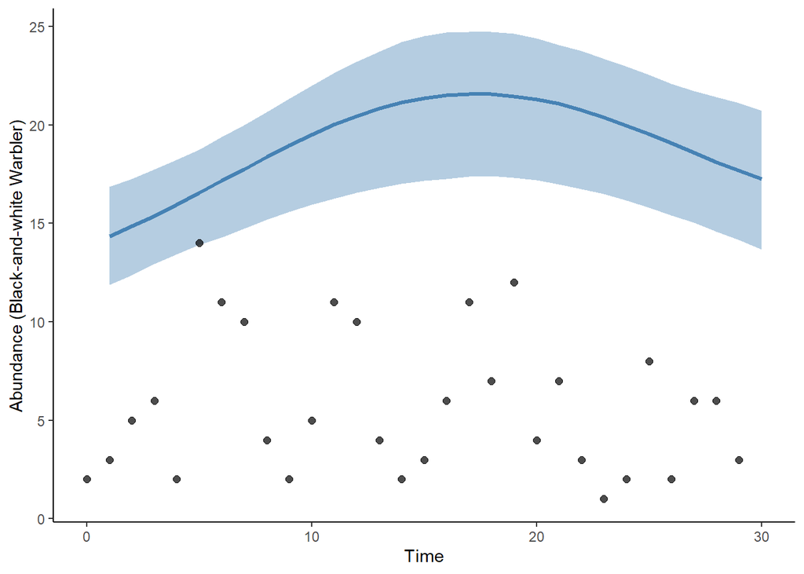

```r
# Visualization: Post-stratified BAWW predictions ----
# Plot the post-stratified trend predictions for Black-and-white Warbler
# Compare with actual BAWW data from the original dataset
actual_BAWW_data <- dat %>%
  filter(series == "Mniotilta varia")

plot_BAWW_poststrat <- ggplot(post_strat_BAWW, aes(x = time, y = estimate)) +
  geom_ribbon(aes(ymax = conf.high, ymin = conf.low),
    colour = NA, fill = "steelblue", alpha = 0.4
  ) +
  geom_line(colour = "steelblue", linewidth = 1.2) +
  geom_point(
    data = actual_BAWW_data,
    aes(x = time, y = y),
    colour = "black", alpha = 0.7, size = 2
  ) +
  theme_classic() +
  labs(
    y = "Abundance (Black-and-white Warbler)",
    x = "Time"
  ) +
  theme(
    plot.title = element_text(size = 12),
    plot.subtitle = element_text(size = 10)
  )

print(plot_BAWW_poststrat)
```

##### 4.4.3.1.5 Anchor and evaluate Post-stratified predictions for BAWW model

The model can predict the shape of the response, but not the scale. Here, *Mniotilta varia* abundance is much lower than predicted. We have a few options to address this; we could choose species with closer ecology and more similar traits for the training model. Weights could be further informed. Alternatively, we can play out the hypothetical where data was collected in some years, but not most. Users of long-term citizen science data will relate to this particular quirk.

```r
# Anchored Post-stratified BAWW Model ----
# Use first year of BAWW data to calibrate the intercept of post-stratified predictions

# Get the first year BAWW observation for anchoring
first_year_BAWW <- actual_BAWW_data %>%
  filter(time == 0) # indexed at 0

# Find the post-stratified prediction for the same time point
first_year_pred <- post_strat_BAWW %>%
  filter(time == 1) # indexed at 1

# Calculate the offset needed to match observed abundance
abundance_offset <- first_year_BAWW$y - first_year_pred$estimate

# Apply offset to all post-stratified predictions
post_strat_BAWW_anchored <- post_strat_BAWW %>%
  mutate(
    estimate_original = estimate,
    conf.low_original = conf.low,
    conf.high_original = conf.high,
    estimate = estimate + abundance_offset,
    conf.low = conf.low + abundance_offset,
    conf.high = conf.high + abundance_offset
  )

mvgam_pred_mean <- post_strat_BAWW_anchored$estimate

# GAM for BAWW
BAWW_gam <- gam(y ~ s(time), data = data_Mniotilta)

# Generate predictions across the time range
gam_pred <- predict(BAWW_gam, type = "response")

# Direction of trend agreement
gam_trend_direction <- sign(diff(gam_pred))
mvgam_trend_direction <- sign(diff(mvgam_pred_mean))
trend_agreement <- mean(gam_trend_direction == mvgam_trend_direction)
trend_agreement
```

```
[1] 0.7931034
```

##### 4.4.3.1.6 Visualize anchored versus original post-stratified predictions

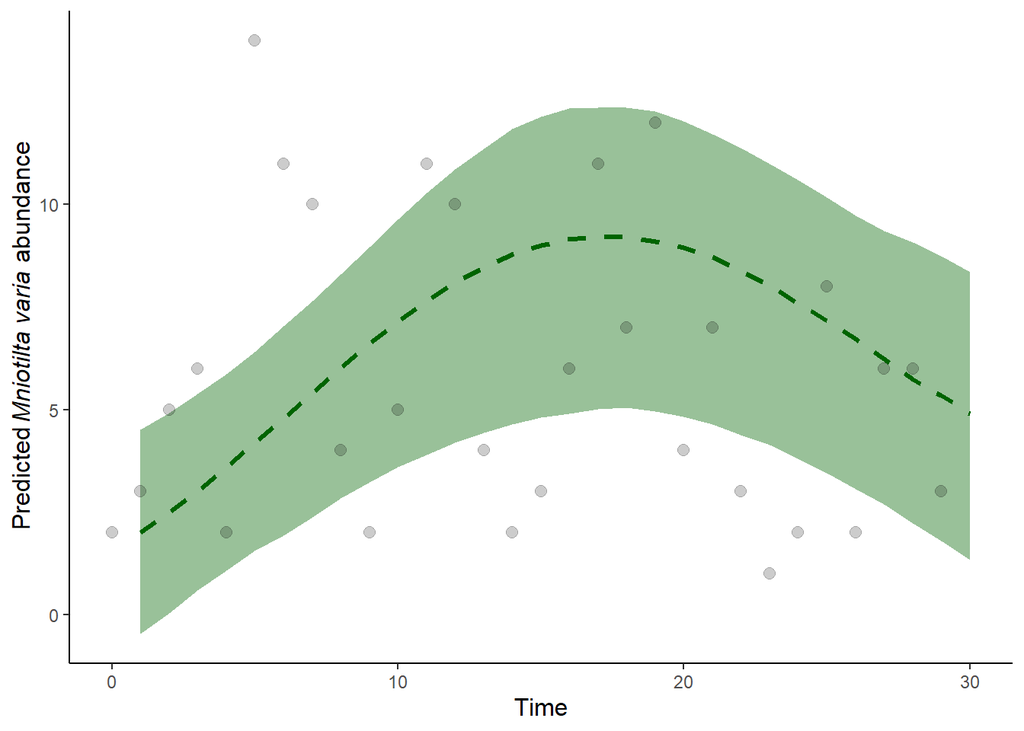

```r
# Visualization: Anchored vs Original Post-stratified Predictions ----
plot_BAWW_anchored <- ggplot() +
  # Anchored post-stratified prediction
  geom_ribbon(
    data = post_strat_BAWW_anchored,
    aes(x = time, ymin = conf.low, ymax = conf.high),
    fill = "darkgreen", alpha = 0.4
  ) +
  geom_line(
    data = post_strat_BAWW_anchored,
    aes(x = time, y = estimate),
    color = "darkgreen", linewidth = 1.2, linetype = "dashed"
  ) +

  # Actual BAWW data
  geom_point(
    data = actual_BAWW_data,
    aes(x = time, y = y),
    colour = "black", alpha = 0.2, size = 2.5
  ) +
  theme_classic() +
  labs(
    y =
      expression(paste("Predicted ", italic("Mniotilta varia"), " abundance")),
    x = "Time"
  ) +
  theme(
    axis.title = element_text(size = 12),
    legend.position = "none"
  )

plot_BAWW_anchored
```

# 5 References

Clark, N. (2023). Temporal autocorrelation in GAMs and the mvgam package. https://ecogambler.netlify.app/blog/autocorrelated-gams/

Pardieck, K. L., Ziolkowski Jr., D. J., and Hudson, M. A. R. (2015). North American Breeding Bird Survey Dataset 1966 - 2014, version 2014.0. https://biotime.st-andrews.ac.uk/selectStudy.php?study=195

Pedersen, E. J., Miller, D. L., Simpson, G. L., & Ross, N. (2019). Hierarchical generalized additive models in ecology: an introduction with mgcv. PeerJ, 7, e6876.

Pedersen, E. J., Koen-Alonso, M., & Tunney, T. D. (2020). Detecting regime shifts in communities using estimated rates of change. ICES Journal of Marine Science, 77(4), 1546-1555